# HW2

```r
transplant <- read.table("~/Desktop/stat5703/HW/HW2/transplant.txt", quote="\"", comment.char="")
colnames(transplant)<-c("time","type","s")
```

####1 Answer: We could assume the right censoring in this data set is random because the death of the plant will occur after the recorded time.

####2

```r
library(ggfortify)
library(survival)
library(dplyr)
```

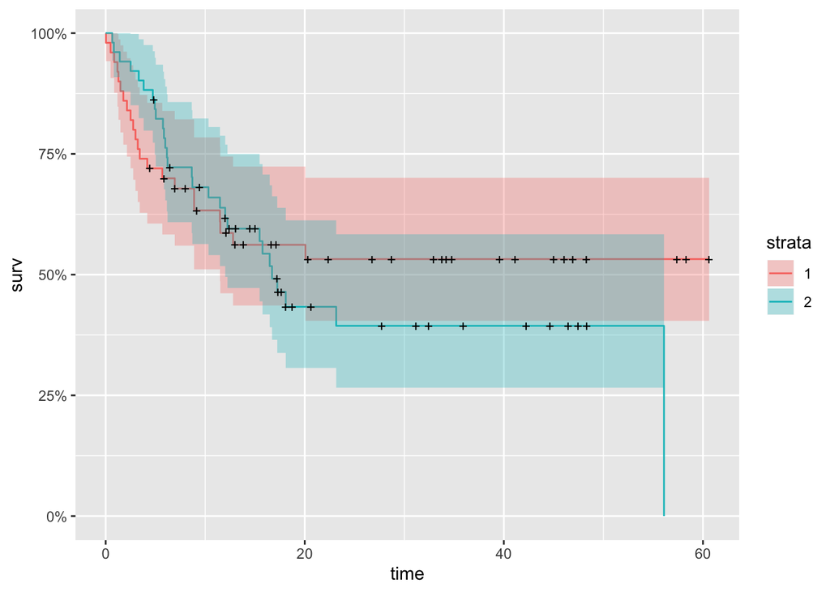

```r
library(ggplot2)
autoplot(survfit(Surv(time, s) ~ type,data=transplant))
```

The plot seem to indicate a difference between two groups. Transplant allogeneic seems to be more efficient.

####3

```r
fit_exp <- survreg(Surv(time,s)~type, dist="exp",data=transplant)
summary(fit_exp)
```

```
##
## Call:
## survreg(formula = Surv(time, s) ~ type, data = transplant, dist = "exp")
##              Value Std. Error     z      p
## (Intercept)  4.066      0.466  8.72 <2e-16
## type        -0.325      0.285 -1.14   0.25
##
## Scale fixed at 1
##
## Exponential distribution
## Loglik(model)= -228   Loglik(intercept only)= -228.6
##  Chisq= 1.31 on 1 degrees of freedom, p= 0.25
## Number of Newton-Raphson Iterations: 5
## n= 101
```

From the summary table, we can see that the estimated value of autologous is a negative value (-0.325). Which means Transplant autologous would cause less survival time. This result is consistant with our previous observation.

####4 From summary table, we get the p value is 0.25 which is larger than normal thresholds 0.05. So there is no strong evidence against the null hypothesis :there is no difference between the transplant type. These conclusion depend on the assumption of exponential parametric model and asymptotic approximation to the distribution of the likelihood ratio statistic.

####5

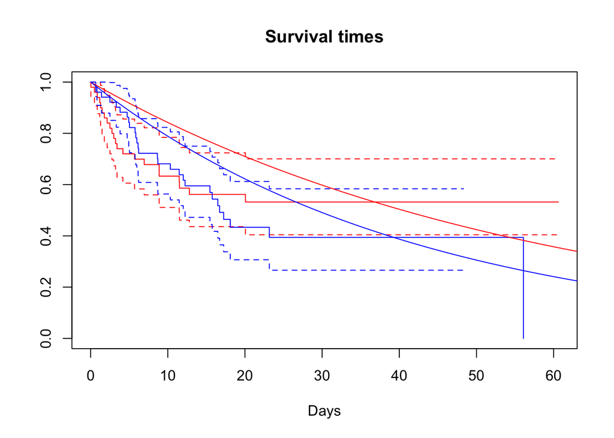

```r
fit<- survfit(Surv(time,s)~type,data=transplant)
par(mfrow=c(1,1))
plot(fit,xlab="Days",conf.int=TRUE,main="Survival times",col=c("red","blue"))

x <- seq(from=0,to=2300,by=1)
lines(x,1-pexp(x,exp(-coef(fit_exp)[1])),col="red")
lines(x,1-pexp(x,exp(-sum(coef(fit_exp)))),col="blue")
```

```r
fit_wei <- survreg(Surv(time,s)~type,data=transplant)
summary(fit_wei)
```

```
##
## Call:
## survreg(formula = Surv(time, s) ~ type, data = transplant)
##              Value Std. Error     z      p
## (Intercept)  4.342      0.698  6.22  5e-10
## type        -0.374      0.420 -0.89 0.3742
## Log(scale)   0.388      0.123  3.15 0.0016
##
## Scale= 1.47
##
## Weibull distribution
## Loglik(model)= -222   Loglik(intercept only)= -222.4
##  Chisq= 0.8 on 1 degrees of freedom, p= 0.37
## Number of Newton-Raphson Iterations: 5
## n= 101
```

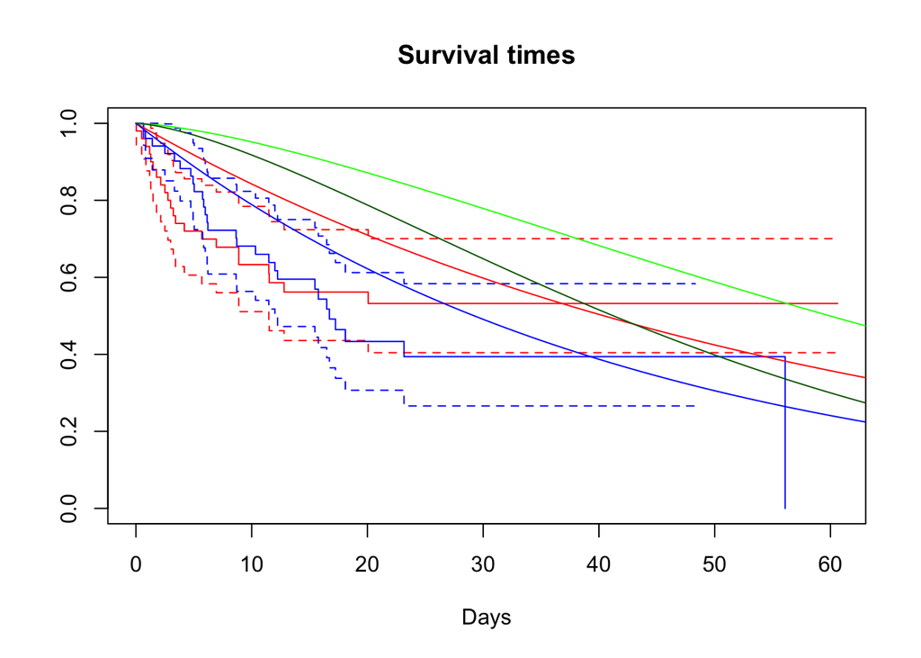

```r
par(mfrow=c(1,1))
plot(fit,col=c("red","blue"),xlab="Days",conf.int=TRUE,main="Survival times")

x <- seq(from=0,to=2300,by=1)
lines(x,1-pexp(x,exp(-coef(fit_exp)[1])),col="red")
lines(x,1-pexp(x,exp(-sum(coef(fit_exp)))),col="blue")

lines(x,1-pweibull(x,fit_wei$scale,exp(coef(fit_wei)[1])),col="green")
lines(x,1-pweibull(x,fit_wei$scale,exp(sum(coef(fit_wei)))),col="darkgreen")
```